# Simulation example for one iteration

Ying Jin

2024-02-14

In this vignette, we will go over the simulation study corresponding to Section 4, using one simulated dataset as an example.

# Data generation

Each simulated subject includes the following components:

- Covariates $\mathbf{X}$: The three covariates associated with survival outcome are generated independently from standard normal distribution.
- True Survival time $T^*$: In this simulation study, the true survival time is generated from a Cox Proportional Hazard Model with Weiball baseline distribution. The log hazard is linearly correlated with covariates as below:

$$log \lambda(t|\boldsymbol{X}) = log
\lambda_0(t) + \boldsymbol{X}^t \boldsymbol{\beta}, t>0$$

with $\boldsymbol{\beta} = (1, -1, 0.25)$ and Weibull baseline hazard $\lambda_0(t) = p\theta t^{p-1}$, $[\theta, p]^t = [2, 2]^t$.

Below is overview of one simulated dataset:

```r
N <- 500 # sample size
Beta <- c(1,-1,0.25) # true coefficient
p <- 3 # number of covariates


X <- matrix(rnorm(N*3), ncol=p, nrow=N) # covariates
Z <- matrix(rnorm(N*100), ncol = 100, nrow = N) # noise
data <- gen_St(eta=X %*% Beta, lambda=2, p=2,
                gen_Ct = function(N){
                  sample(c(0.5, 1), size = N, replace = T)}) # outcome
data <- rename(data, true_eta = eta)
data$X <- I(X)
data$Z <- I(Z)
```

Once the data is generated, we need to split the sample into training and testing set. We use 50% of the subjects as the traininig set and the rest as the testing set.

```r
N_obs <- N*0.5
data_train <- data[1:N_obs,]
data_test  <- data[-c(1:N_obs),]
```

Below is an example of survival curves on one simualted dataset

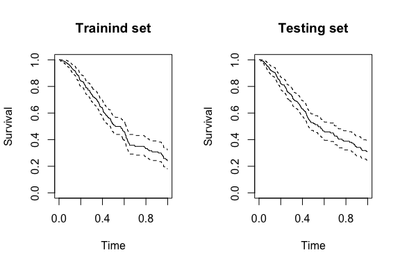

```r
par(mfrow = c(1, 2))
# Kaplan-Meier curve
plot(survfit(Surv(time, event)~1, data = data_train), xlab = "Time", ylab = "Survival",
     main = "Trainind set")
plot(survfit(Surv(time, event)~1, data = data_test), xlab = "Time", ylab = "Survival",
     main = "Testing set")
```

# Model overfit

To investigate the effect of model overfit on the behavior of estimators, we fit three different Cox Proportional Hazard models

1. Not overfitted: $log \lambda(t|\boldsymbol{X}) = log \lambda_0(t) + \boldsymbol{X}^t \boldsymbol{\beta}$
2. Moderately overfitted: $log \lambda(t|\boldsymbol{X}) = log \lambda_0(t) + \boldsymbol{X}^t \boldsymbol{\beta}+\sum_{j=1}^{20}Z_j\gamma_j$
3. Severely overfitted: $log \lambda(t|\boldsymbol{X}) = log \lambda_0(t) + \boldsymbol{X}^t \boldsymbol{\beta}+\sum_{j=1}^{100}Z_j\gamma_j$

## Cox models

```r
# Fit cox models on training data
# true model
fit_1 <- tryCatch(expr = coxph(Surv(time, event) ~ X, data=data_train), warning = function(x){NULL})
# moderately overfitted
fit_2 <- tryCatch(expr = coxph(Surv(time, event) ~ X + Z[,1:20], data=data_train),
                    warning = function(x){NULL})
# severely overfitted
fit_3 <- tryCatch(expr = coxph(Surv(time, event) ~ X + Z, data=data_train),
                    warning = function(x){NULL})
```

## Incident/Dynamic AUC estimators

In this simulation study, we well compare the following three estimators:

- Heagerty & Zheng estimator (HZ). This is a semi-parametric estimator, since it incorporates the term $exp(\boldsymbol{X}^T\boldsymbol{\beta})$ as weights for estimation of sensitivity.
- Non-parametric estimator (NP). This estimators is established on plug-in principals, using the proportion of true positive and true negative observations for estimation of sensitivity and specificity, respectively.
- Smoothed non-parametric estimator (SNP). This is a smoothed version of the non-parametric estimator above.

At a specificity time point, all three methods estimate sensitivity and specificity at a series of discrete values of $\boldsymbol{X}^T\boldsymbol{\beta}$ to get an ROC curve, and use its integral as estimate of Incident/Dynamic AUC.

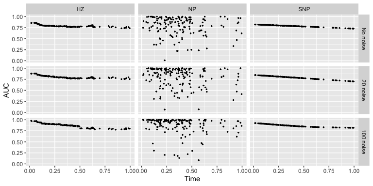

```r
# in-sample estimates
# unique time and biomarker values of training sample
t_uni_train <- unique(data_train$time[data_train$event==1])
nt_uni_train <- length(t_uni_train)

# AUC estimates
auc_est1 <- tv_auc(fit_1$linear.predictors, data_train, t_uni_train, nt_uni_train)
auc_est2 <-  tv_auc(fit_2$linear.predictors, data_train, t_uni_train, nt_uni_train)
auc_est3 <-  tv_auc(fit_3$linear.predictors, data_train, t_uni_train, nt_uni_train)

# plot
bind_rows(data.frame(auc_est1), data.frame(auc_est2), data.frame(auc_est3), .id = "Model") %>%
  mutate(Model = factor(Model, levels = 1:3, labels = c("No noise", "20 noise", "100 noise")),
) %>%
  pivot_longer(3:5) %>%
  ggplot(aes(x=time, y=value))+
  geom_point(size = 0.5)+
  facet_grid(rows = vars(Model), col = vars(name))+
  labs(x="Time", y="AUC")
```

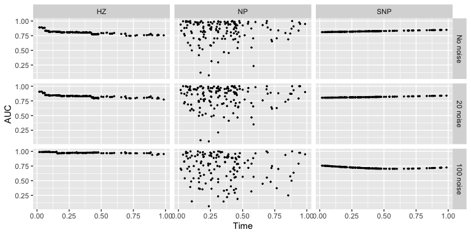

```r
# out-of-sample estimates
# estimated risk scores
## based on model trained in-sample
test_eta1 <- as.vector(data_test$X %*% coef(fit_1))
test_eta2 <- as.vector(cbind(data_test$X,data_test$Z[,1:20]) %*% coef(fit_2))
test_eta3 <- as.vector(cbind(data_test$X,data_test$Z) %*% coef(fit_3))

# unique event time in the test set
t_uni_test <- unique(data_test$time[data_test$event==1])
nt_uni_test <- length(t_uni_test)

#  AUC estimates
test_auc_est1 <- tv_auc(test_eta1, data_test, t_uni_test, nt_uni_test)
test_auc_est2 <- tv_auc(test_eta2, data_test, t_uni_test, nt_uni_test)
test_auc_est3 <- tv_auc(test_eta3, data_test, t_uni_test, nt_uni_test)

# plot
bind_rows(data.frame(test_auc_est1), data.frame(test_auc_est2), data.frame(test_auc_est3),
          .id = "Model") %>%
  mutate(Model = factor(Model, levels = 1:3, labels = c("No noise", "20 noise", "100 noise"))) %>%
  pivot_longer(3:5) %>%
  ggplot(aes(x=time, y=value))+
  geom_point(size = 0.5)+
  facet_grid(rows = vars(Model), col = vars(name))+
  labs(x="Time", y="AUC")
```

## Concordance estimators:

Here we compare the behavior of the following estimators:

- Semi-parmaetric: Heagerty-Zheng, Gonen-Heller
- Non-parametric: weighted integral of non-parametric AUC, weighted integral of smoothed non-parametric AUC, Harrell’s C-index.

Please note that for weighted integral, the weight of Incident/Dynamic AUC at a specific time points is derived from marginal survival and density function of survival time. The semi-parametric concordance proposed by Heagerty & Zheng used Kaplan-Meier estimator directly. However, this paper proposed the use of smoothed Kaplan-Meier curve.

```r
# in-sample
KM_fit_train <- survfit(Surv(time,event)~1, timefix=FALSE, data=data_train)
KM_est_train <- KM_fit_train$surv[KM_fit_train$n.event>0]
# out-of-sample
KM_fit_test <- survfit(Surv(time,event)~1, timefix=FALSE, data=data_test)
KM_est_test <- KM_fit_test$surv[KM_fit_test$n.event>0]
```

```r
# in-sample
concord1 <- concord(data_train, KM_est_train, auc_est1, fit_1$coefficients,
                    data_train$X)
concord2 <- concord(data_train, KM_est_train, auc_est2, fit_2$coefficients,
                    cbind(data_train$X, data_train$Z[, 1:20]))
concord3 <- concord(data_train, KM_est_train, auc_est3, fit_3$coefficients,
                    cbind(data_train$X, data_train$Z))
# out-of-sample
test_concord1 <- concord(data_test, KM_est_test, test_auc_est1, fit_1$coefficients, data_test$X)
test_concord2 <- concord(data_test, KM_est_test, test_auc_est2, fit_2$coefficients,
                         cbind(data_test$X, data_test$Z[, 1:20]))
test_concord3 <- concord(data_test, KM_est_test, test_auc_est3, fit_3$coefficients,
                         cbind(data_test$X, data_test$Z))
```

Now let’s take a brief look at the results:

| Model | In-sample GH | In-sample HZ | In-sample Harrell’s | In-sample NP | In-sample SNP | Out-of-sample GH | Out-of-sample HZ | Out-of-sample Harrell’s | Out-of-sample NP | Out-of-sample SNP |
| --- | --- | --- | --- | --- | --- | --- | --- | --- | --- | --- |
| No noise | 0.779 | 0.784 | 0.798 | 0.766 | 0.791 | 0.795 | 0.809 | 0.822 | 0.833 | 0.823 |
| 20 noise | 0.795 | 0.799 | 0.807 | 0.765 | 0.796 | 0.808 | 0.834 | 0.813 | 0.815 | 0.813 |
| 100 noise | 0.888 | 0.878 | 0.884 | 0.850 | 0.874 | 0.910 | 0.978 | 0.728 | 0.724 | 0.725 |